# schlacks-michelle-projectcheckpoint3

## How little do you actually know about shootings in the US?

By: Michelle Schlacks

- To start off I wanted to show a visualization that I found from an article called visualizing mass shooting. I thought it was quite interesting and devastating.

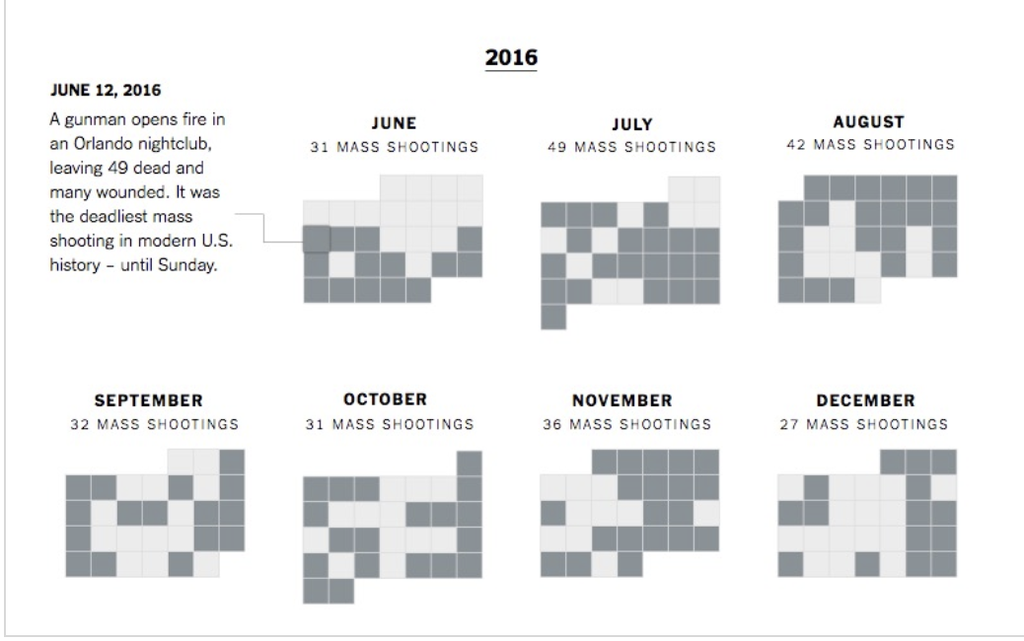

(New York Times)

```python
import pandas as pd
%matplotlib inline
import ipywidgets

df = pd.read_csv('/Users/michelleschlacks/Desktop/shootings.csv', encoding = "unicode_escape")

@ipywidgets.interact(style=plt.style.available)
def make_plot(style):
    with plt.style.context(style): # this style is applied ONLY to this plot and not following
        fig, ax = plt.subplots(1,1,figsize=(15,5))
        ax.scatter(df["Age"].sort_values(), df["Fatalities"].sort_values(), marker= '+')
        ax.set_xlabel("Age")
        ax.set_ylabel("Fatalities")




    plt.show()
```

[output not shown]

- The main reason I focused on this dataset, is because shootings are every day becoming more and more of an issue in the United States. And form what I have seem it just seems like there is no way to solve it.
- Here is another visualization that made a huge impact on me and tells a devastating story. Here it is showing how in the past month, past month being March of 2021, there have been 45 MASS shootings. It is not okay, and something needs to be done.

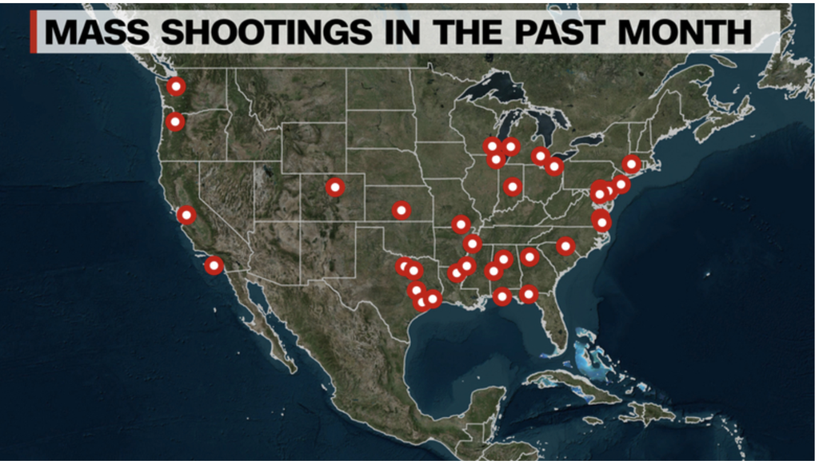

(CNN politics)

Works Cited:

- https://source.opennews.org/articles/visualizing-mass-shootings/
- https://www.cnn.com/2021/04/16/politics/mass-shootings-america-guns/index.html